# Evolution in DDD use of Diabetes Drugs over time

code

analysis

exploration

cost

drugs

Author

Henrik Vitus Bering Laursen

Published

September 30, 2024

## Drug utilisation over time

My two previous posts examined data available from medstat and were focused on those datasets and specifically the turnover of specific drug classes.

Here, I wish to demonstrate a different type of publicly available data, still related to prescription data.

This is data regarding drug prices, and can be found on The Danish Health Data Authority’s website [here](https://www.esundhed.dk/Emner/Laegemidler/Medicinpriser).

Danish drug prices are by and large renegotiated every 14 days. Therefore, the dataset is updated accordingly. I will use the data from the most [recent update](https://www.esundhed.dk/-/media/Files/Publikationer/Emner/Laegemidler/Medicinpriser/2024/lmpriser_eSundhed_240916.ashx) as of the start of making this post.

Looking at it post hoc, I used the following packages:

```r
library(tidyverse)
library(readxl)
library(httr)
library(stringr)
library(extrafont)
# install.packages("ggpubr")
# library(gridExtra)
# library(ggpubr)
```

### Fetching the data

I had some initial trouble figuring out how to download the file. What kept me from figuring it out was not realising that the file from the [link](https://www.esundhed.dk/-/media/Files/Publikationer/Emner/Laegemidler/Medicinpriser/2024/lmpriser_eSundhed_240916.ashx) was a zip file containing an excel file.

Apparently, “The extension .ashx doesn’t specify the file format but rather that a server-side handler is being used to serve the content.”, as chatGPT puts it. I have no gained the understanding that .ashx is just some sort of framework that serves up the data, not a file type.

This leads to the following code necessary to download the data. Code is just for show.

```r
# URL of the .ashx file
url <- "https://www.esundhed.dk/-/media/Files/Publikationer/Emner/Laegemidler/Medicinpriser/2024/lmpriser_eSundhed_240916.ashx"

# Define a path in my local datafolder, used as described in the first post about medstat data
datapath <- "C:/Users/henri/Documents/data-publicdataprojects"

# Define the path where the ZIP file will be saved
zip_destfile <- paste0(datapath,"lmpriser_eSundhed_240916.zip")

# Download the ZIP file
download.file(url, zip_destfile, mode = "wb")

# Unzip the file
unzip(zip_destfile, exdir = paste0(datapath,"unzipped_files"))

# Check the unzipped files
list.files(paste0(datapath,"unzipped_files"))

# check which sheet to import from the excel file
sheet_names <- excel_sheets(paste0(datapath,"unzipped_files/lmpriser_eSundhed_240916.xlsx"))
```

And then I import the file:

```r
# Read the excel file
datapath <- "C:/Users/henri/Documents/data-publicdataprojects"
df_ddd <- read_excel(paste0(datapath,"unzipped_files/lmpriser_eSundhed_240916.xlsx"), sheet = "lmpriser_eSundhed_240916")

head(df_ddd)
```

```
# A tibble: 6 × 144
  ATC    Lægemiddel Indholdsstof Varenummer Pakning Styrke Form  Firma Indikator
  <chr>  <chr>      <chr>        <chr>      <chr>   <chr>  <chr> <chr> <chr>
1 A01AA… Duraphat   Natriumfluo… 066411     51 g    5 mg/g tand… Colg… AIP
2 A01AA… Duraphat   Natriumfluo… 066411     51 g    5 mg/g tand… Colg… AUP
3 A01AA… Duraphat   Natriumfluo… 066411     51 g    5 mg/g tand… Colg… DDD
4 A01AA… Duraphat   Natriumfluo… 066411     51 g    5 mg/g tand… Colg… AUP_pr_D…
5 A01AA… Duraphat   Natriumfluo… 066422     3 x 51… 5 mg/g tand… Colg… AIP
6 A01AA… Duraphat   Natriumfluo… 066422     3 x 51… 5 mg/g tand… Colg… AUP
# ℹ 135 more variables: `20190729` <dbl>, `20190812` <dbl>, `20190826` <dbl>,
#   `20190909` <dbl>, `20190923` <dbl>, `20191007` <dbl>, `20191021` <dbl>,
#   `20191104` <dbl>, `20191118` <dbl>, `20191202` <dbl>, `20191216` <dbl>,
#   `20191230` <dbl>, `20200113` <dbl>, `20200127` <dbl>, `20200210` <dbl>,
#   `20200224` <dbl>, `20200309` <dbl>, `20200323` <dbl>, `20200406` <dbl>,
#   `20200420` <dbl>, `20200504` <dbl>, `20200518` <dbl>, `20200601` <dbl>,
#   `20200615` <dbl>, `20200629` <dbl>, `20200713` <dbl>, `20200727` <dbl>, …
```

### Cleaning the data

Just as the post, I want to focus on drugs used for diabetes. So I keep only the observations with A10A and A10B:

```r
# Cleaning it in one set of operations
df_ddd_A10 <- df_ddd |>
# Filter for just A10A and A10B, and keep just prp per ddd
  filter(
    str_detect(ATC,("^A10B")) | str_detect(ATC,("^A10A")),
    Indikator == "AUP_pr_DDD") |>
  # Select variables
  select(ATC, Indholdsstof, Lægemiddel, starts_with("20")) |>
  # Pivot the data so that the variable columns that contain time are contained in one variable column
  pivot_longer(
    cols = starts_with("20"),
    names_to = "Tid",
    values_to = "prpddd") |>
  mutate(
    Tid = ymd(Tid)) |>
  # group_by(tid) |>  DELETE??
  # mutate(
  #   hip_ddd = max(prpddd), # hip_ddd = maxpris per ddd
  #   lop_ddd = min(prpddd) # lop_ddd = minpris per ddd
  # ) |>
  # ungroup() |>
  filter(
    !is.na(prpddd)
  )

# And translate the colnames to english for good measure
head(df_ddd_A10)
```

```
# A tibble: 6 × 5
  ATC     Indholdsstof    Lægemiddel Tid        prpddd
  <chr>   <chr>           <chr>      <date>      <dbl>
1 A10AB01 Insulin (human) Actrapid   2019-07-29   6.48
2 A10AB01 Insulin (human) Actrapid   2019-08-12   6.48
3 A10AB01 Insulin (human) Actrapid   2019-08-26   6.48
4 A10AB01 Insulin (human) Actrapid   2019-09-09   6.48
5 A10AB01 Insulin (human) Actrapid   2019-09-23   6.48
6 A10AB01 Insulin (human) Actrapid   2019-10-07   6.48
```

```r
colnames(df_ddd_A10) <- c(
  "atc",
  "compound",
  "product",
  "time",
  "prpddd" # Pharmacy Retail Price DDD
)
head(df_ddd_A10)
```

```
# A tibble: 6 × 5
  atc     compound        product  time       prpddd
  <chr>   <chr>           <chr>    <date>      <dbl>
1 A10AB01 Insulin (human) Actrapid 2019-07-29   6.48
2 A10AB01 Insulin (human) Actrapid 2019-08-12   6.48
3 A10AB01 Insulin (human) Actrapid 2019-08-26   6.48
4 A10AB01 Insulin (human) Actrapid 2019-09-09   6.48
5 A10AB01 Insulin (human) Actrapid 2019-09-23   6.48
6 A10AB01 Insulin (human) Actrapid 2019-10-07   6.48
```

### Prepping data for plotting

The resulting dataset is one with all registered Pharmacy Retail Price per Defined Daily Dose (PRP per DDD) of Drugs in the A10 ATC category, from between 2019-07-29 and 2024-09-16. In other words: from the past 5.1362081 years.

This is basically a measure of how much it costs to treat a person with the medication with a standard dose, each day, and can be used to compare how much each drug costs to use for treatment. This is used because it can be difficult to compare drugs based on redeemed prescriptions or prices, as some drugs are prescribed differently than others. Also, some drugs have absurdly high prices per pill, as some specialised drugs in oncology and opthalmology, compared to very cheap generic pain killers.

This is exemplified in the code below.

```r
df_ddd_test <- df_ddd |>
  filter(Indikator == "AUP") |> # AUP = Pharmacy Retail Price
  pivot_longer(
    cols = starts_with("20"),
    names_to = "Tid",
    values_to = "prp"
    ) |>
    summarise(
    highest_prp = max(prp, na.rm = TRUE),
    lowest_prp = min(prp, na.rm = TRUE)
  )
df_ddd_test
```

```
# A tibble: 1 × 2
  highest_prp lowest_prp
        <dbl>      <dbl>
1    9999990.       7.25
```

I want to present the numbers with inline code, and this can be done easily with the basic R function `format()` and `cat()` which can format the numeric value and concatenate the text.

```r
# Format the numbers in base R
formatted_highest_prp <- format(df_ddd_test$highest_prp, big.mark = ",", scientific = FALSE)
formatted_lowest_prp <- format(df_ddd_test$lowest_prp, big.mark = ",", scientific = FALSE)

# Print the formatted numbers
cat("Highest AUP:", formatted_highest_prp, "DKK\n")
```

```
Highest AUP: 9,999,990 DKK
```

```r
cat("Lowest AUP:", formatted_lowest_prp, "DKK\n")
```

```
Lowest AUP: 7.25 DKK
```

### Making a plot

Now, back to the retail price per DDD of diabetes drugs. Just as a visual aid, lets compare the most expensive to the cheapest, of the diabetes drugs.

But before that, a useful thing I picked up from [Meghan Hall’s blog](https://meghan.rbind.io/), is putting a consistent theme on your plots. This can be done as below.

```r
library(gghighlight)
library(scales)
library(ggtext)
library(ggrepel)

hen_theme <- function () {
  theme_linedraw(base_size=11) %+replace%
    theme(
      panel.background  = element_blank(),
      plot.background = element_rect(fill = "white", color = NA),
      legend.background = element_rect(fill = "white", color = NA),
      legend.key = element_rect(fill = "white", color = NA),
      axis.ticks = element_blank(),
      panel.grid.major = element_line(color = "grey90", size = 0.3),
      panel.grid.minor = element_blank(),
      plot.title.position = "plot",
      plot.title = element_text(size = 16, hjust = 0, vjust = 0.5,
                                margin = margin(b = 0.2, unit = "cm")),
      plot.subtitle = element_text(size = 10, hjust = 0, vjust = 0.5,
                                   margin = margin(b = 0.4, unit = "cm")),
      plot.caption = element_text(size = 7, hjust = 1, face = "italic",
                                  margin = margin(t = 0.1, unit = "cm")),
      axis.text.x = element_text(size = 13),
      axis.text.y = element_text(size = 13)
    )
}
```

The “hen_theme” is then added to future plots, at the end.

```r
# find most expensive
df_ddd_A10 |>
  group_by(atc) |>
  summarise(
    highest_prpddd = max(prpddd, na.rm = TRUE),
    lowest_prpddd = min(prpddd, na.rm = TRUE)
  ) |>
  summarise(
    most_expensive_atc = atc[which.max(highest_prpddd)],
    most_expensive_value = max(highest_prpddd),
    least_expensive_atc = atc[which.min(lowest_prpddd)],
    least_expensive_value = min(lowest_prpddd)
  )
```

```
# A tibble: 1 × 4
  most_expensive_atc most_expensive_value least_expensive_atc
  <chr>                             <dbl> <chr>
1 A10BX16                            522. A10BB12
# ℹ 1 more variable: least_expensive_value <dbl>
```

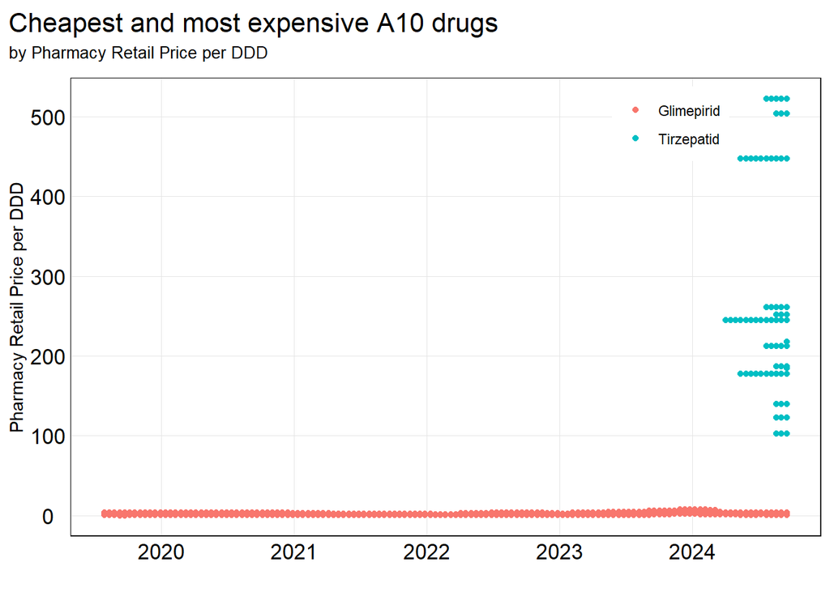

```r
# plot
hilo_ddd <- df_ddd_A10 |>
  filter(atc == "A10BX16" | atc == "A10BB12") |>
  select(compound,time,prpddd)

ggplot(hilo_ddd, mapping = aes(x=time,y=prpddd, colour = compound)) +
  geom_point() +
  labs(
    title = "Cheapest and most expensive A10 drugs",
    subtitle = "by Pharmacy Retail Price per DDD",
    y = "Pharmacy Retail Price per DDD",
    x = "",
  ) +
  hen_theme() +
  theme(
    legend.title = element_blank(),
    legend.position = c(0.8,0.9),
    legend.background = element_rect(fill= "white")
    )
```

This plot tells us that the two drug compounds with the highest and lowest PRP per DDD are Glimepiride, of the [sulfonyurea](https://en.wikipedia.org/wiki/Sulfonylurea) class, and Tirzepatide, a [GIP](https://en.wikipedia.org/wiki/Gastric_inhibitory_polypeptide_receptor) and [GLP1](https://en.wikipedia.org/wiki/GLP-1_receptor_agonist) combination.

Now, I wish to visualise how PRP per DDD changes over time. Below, I create the variables for the minimum and maximum values for each compound.

```r
# Make a new var thats floored to months and find the min for each month
df_ddd_A10_minmax <- df_ddd_A10 |>
  mutate(month = floor_date(time,"month")) |>
  group_by(month, atc, compound) |>
  summarise(
    a_min_prpddd = min(prpddd, na.rm = TRUE), # "a_" is to make it first in the facetwrap later
    b_max_prpddd = max(prpddd, na.rm = TRUE)) |>
  ungroup()
head(df_ddd_A10_minmax)
```

```
# A tibble: 6 × 5
  month      atc     compound         a_min_prpddd b_max_prpddd
  <date>     <chr>   <chr>                   <dbl>        <dbl>
1 2019-07-01 A10AB01 Insulin (human)          6.07         9.90
2 2019-07-01 A10AB04 Insulin lispro           9.8         12.2
3 2019-07-01 A10AB05 Insulin aspart           9.66        13.1
4 2019-07-01 A10AB06 Insulin glulisin         9.35         9.55
5 2019-07-01 A10AC01 Insulin (human)          6.07        10.9
6 2019-07-01 A10AD01 Insulin (human)          6.34        10.9
```

And now for the grand plot I have planned for this post, which will be an overview of the PRP per DDD for the main drug classes in diabetes type 2 treatment.

First, I limit the dataset to only encompass the classes I want to look at.

```r
dfforplot <- df_ddd_A10_minmax |>
  filter(
    str_detect(atc,"^A10BA") |   # met
      str_detect(atc,"^A10BB") | # sul
      str_detect(atc,"^A10BK") | # sglt2
      str_detect(atc,"^A10BJ") | # glp1
      str_detect(atc,"^A10BH") | # dpp4
      str_detect(atc,"^A10BX16") # tirzepatid, honoured guest
    )
```

Then, I try to make the plots which contain a surmountable amount of information.

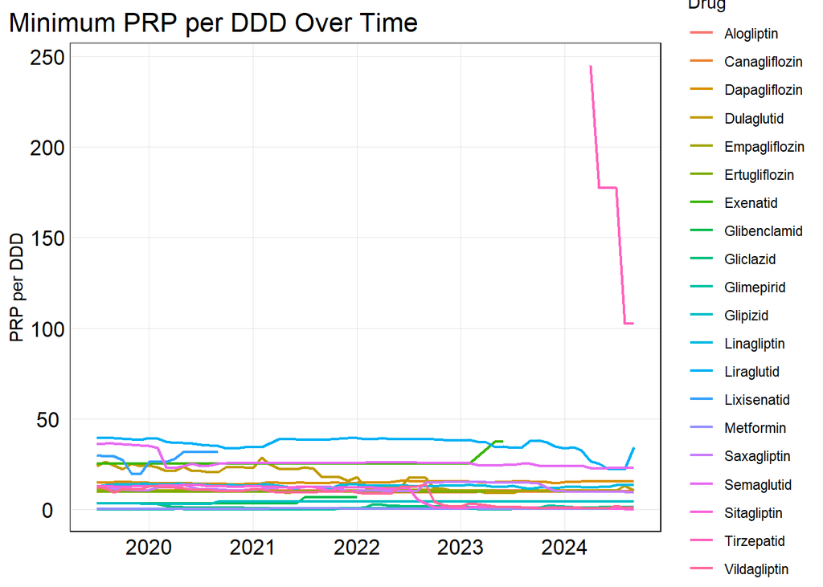

```r
# Minimum values plot
plotmin <- ggplot(dfforplot) +
  geom_line(aes(x = month, y = a_min_prpddd, colour = compound), linewidth = 0.8) +
  labs(title = "Minimum PRP per DDD Over Time",
       x = "",
       y = "PRP per DDD",
       colour = "Drug") +
  hen_theme()
# Max
plotmax <- ggplot(dfforplot) +
  geom_line(aes(x = month, y = b_max_prpddd, colour = compound), linewidth = 0.8) +
  labs(title = "Maximum PRP per DDD Over Time",
       x = "",
       y = "PRP per DDD",
       colour = "Drug") +
  hen_theme()

plotmin
```

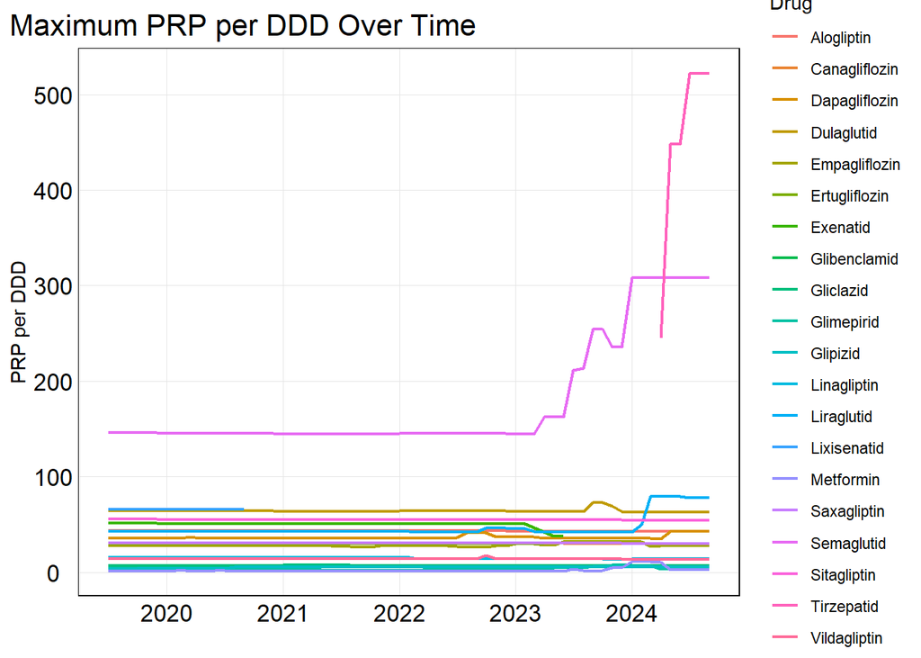

```r
plotmax
```

Now that is quite the jumble of lines.

I want to do the following:

- Create a more meaningful colour representation
- Look at the outliers separately from the ones staying below 50 and 100, respectively.

First, meaningful colour representation.

The exact amount of different compounds within each class can be found via the code below.

```r
dfforplot |> group_by(atc) |> distinct(compound)
```

```
# A tibble: 20 × 2
# Groups:   atc [20]
   atc     compound
   <chr>   <chr>
 1 A10BA02 Metformin
 2 A10BB01 Glibenclamid
 3 A10BB07 Glipizid
 4 A10BB09 Gliclazid
 5 A10BB12 Glimepirid
 6 A10BH01 Sitagliptin
 7 A10BH02 Vildagliptin
 8 A10BH03 Saxagliptin
 9 A10BH04 Alogliptin
10 A10BH05 Linagliptin
11 A10BJ01 Exenatid
12 A10BJ02 Liraglutid
13 A10BJ03 Lixisenatid
14 A10BJ05 Dulaglutid
15 A10BJ06 Semaglutid
16 A10BK01 Dapagliflozin
17 A10BK02 Canagliflozin
18 A10BK03 Empagliflozin
19 A10BK04 Ertugliflozin
20 A10BX16 Tirzepatid
```

Now we can setup a vector with colour mapping using the output from above. Copy and paste it into a text editor to convert it to something useful. There are probably smarter ways to use that output.

```r
# prep colour scheme for drugs

colour_mapping <- c(
  # Unique drug
  "Metformin"       = "#000000",  # Deep Blue (for uniqueness)

  # Sulfonylureas (reddish colors)
  "Glibenclamid"    = "#d62728",  # Red
  "Glipizid"        = "#e37777",  # Light Red
  "Gliclazid"       = "#c13515",  # Darker Red
  "Glimepirid"      = "#ff6347",  # Tomato Red

  # DPP-4 inhibitors (greenish colors)
  "Sitagliptin"     = "#2ca02c",  # Green
  "Vildagliptin"    = "#98df8a",  # Light Green
  "Saxagliptin"     = "#34a56f",  # Teal Green
  "Alogliptin"      = "#57a774",  # Medium Green
  "Linagliptin"     = "#1e7f5f",  # Dark Green

  # GLP-1 receptor agonists (bluish colors)
  "Exenatid"        = "#1f77b4",  # Deep Blue
  "Liraglutid"      = "#5b9bd5",  # Light Blue
  "Lixisenatid"     = "#6495ed",  # Cornflower Blue
  "Dulaglutid"      = "#4682b4",  # Steel Blue
  "Semaglutid"      = "#4169e1",  # Royal Blue

  # SGLT2 inhibitors (yellowish and brownish colors)
  "Dapagliflozin"   = "#ffd700",  # Gold
  "Canagliflozin"   = "#e5b33f",  # Dark Yellow
  "Empagliflozin"   = "#d9a120",  # Mustard
  "Ertugliflozin"   = "#b8860b",  # Dark Goldenrod

  # Tirzepatide (distinct color)
  "Tirzepatid"      = "#8b008b"   # Dark Magenta
)
```

Now to look at the ones who are not outliers separately to see if the graph is visually meaningful.

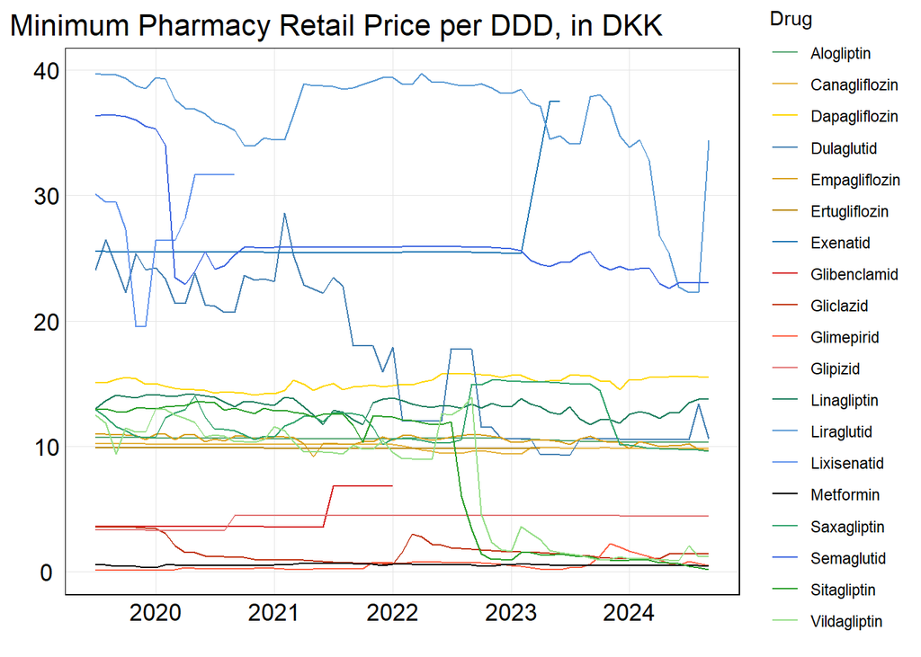

```r
testplot1 <- ggplot(dfforplot |> filter(a_min_prpddd<100), aes(x = month, y = a_min_prpddd, colour = compound)) +
  geom_line() +
  scale_colour_manual(values = colour_mapping) +
  scale_x_continuous(breaks = seq.Date(as.Date("2020-01-01"), as.Date("2025-12-01"), by = "year"),
                     labels = format(seq.Date(as.Date("2020-01-01"), as.Date("2025-12-01"), by = "year"), "%Y")) +
  labs(title = "Minimum Pharmacy Retail Price per DDD, in DKK",
       x = "",
       y = "",
       colour = "Drug") +
  hen_theme()

testplot1
```

First of all, this is a mess. In addition to looking at the outliers separately, I want to do the following:

1. Sort the legend according to drug class (atc codes)
2. Reduce the amount of compounds included

For (1), y’all need to hold on for dear life because this stuff is an amalgamation of what I have done in my PhD combined with some new things. I will have to explain each part of the code in great detail to even remember how this works.

*The explanations are maybe mostly for me*.

To achieve that, I will firstly make a variable with a label for each drug class. Then, I will order the compound variable by the class variable. Then I apply cus tom colours to the compound variable.

The first part is relatively simply done using `case_when()` and knowledge of what classes the ATC codes represent.

```r
dfforplot <- dfforplot |>
  mutate(class = case_when(
    substr(atc, 1, 5) == "A10BA" ~ "Metformin",
    substr(atc, 1, 5) == "A10BB" ~ "Sulfonylureas",
    substr(atc, 1, 5) == "A10BH" ~ "DPP4",
    substr(atc, 1, 5) == "A10BJ" ~ "GLP1",
    substr(atc, 1, 5) == "A10BK" ~ "SGLT2",
    substr(atc, 1, 5) == "A10BX" ~ "Tirzepatide",
    TRUE ~ "Other"  # For any other unclassified codes
  ))
```

For the second part, I set the order I want, turn the `class` variable into a factor, and then `arrange()` the compounds within each class according to this order. Finally, I turn the compound variable into a factor that is ordered by its unique levels, which correspond to the classes, and check that `compound` has the correct order.

```r
class_order <- c("Metformin", "Sulfonylureas", "DPP4", "GLP1", "SGLT2", "Tirzepatide")
dfforplot <- dfforplot |>
  mutate(class = factor(class, levels = class_order))  |>
  arrange(class, compound) |>
  mutate(compound = factor(compound, levels = unique(compound)))
print(levels(dfforplot$compound))
```

```
 [1] "Metformin"     "Glibenclamid"  "Gliclazid"     "Glimepirid"
 [5] "Glipizid"      "Alogliptin"    "Linagliptin"   "Saxagliptin"
 [9] "Sitagliptin"   "Vildagliptin"  "Dulaglutid"    "Exenatid"
[13] "Liraglutid"    "Lixisenatid"   "Semaglutid"    "Canagliflozin"
[17] "Dapagliflozin" "Empagliflozin" "Ertugliflozin" "Tirzepatid"
```

The third part is simply remembering the order of classes, and how many compounds are within each class, and then creating a selection of colours via the `colorRampPallette()` function, and then store that in the object `colours_compunds`, to use in the plot.

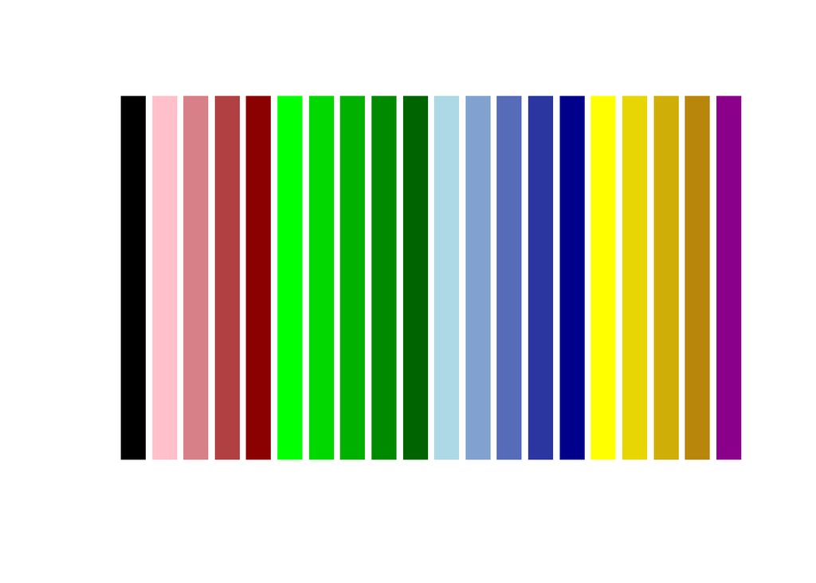

```r
met_colours  <- colorRampPalette(c("black"))(1)
su_colours  <- colorRampPalette(c("pink","darkred"))(4)
dpp4_colours   <- colorRampPalette(c("green","darkgreen"))(5) # NB THIS WORKS BECAUSE THE FIRST 5 ARE DPP4, 6 are GLP1, etc etc.
glp1_colours   <- colorRampPalette(c("lightblue","darkblue"))(5)
sglt2_colours  <- colorRampPalette(c("yellow","#b8860b"))(4)
tir_colours  <- colorRampPalette(c("#8b008b"))(1)
colours_compounds <- c(met_colours,
                su_colours,
                dpp4_colours,
                glp1_colours,
                sglt2_colours,
                tir_colours) # combine
barplot(rep(1,20), col=colours_compounds, border = "white", axes = FALSE)
```

```r
kept_compounds <- c(
  "Metformin",
  "Glipizid",
  "Gliclazid",
  "Glimepirid",
  "Sitagliptin",
  "Vildagliptin",
  "Linagliptin",
  "Liraglutid",
  "Dulaglutid",
  "Semaglutid",
  "Dapagliflozin",
  "Canagliflozin",
  "Empagliflozin",
  "Tirzepatid"
)
```

Now, lets make plots for the ones that are not outliers. In practice I will do that by just limiting the y axis.

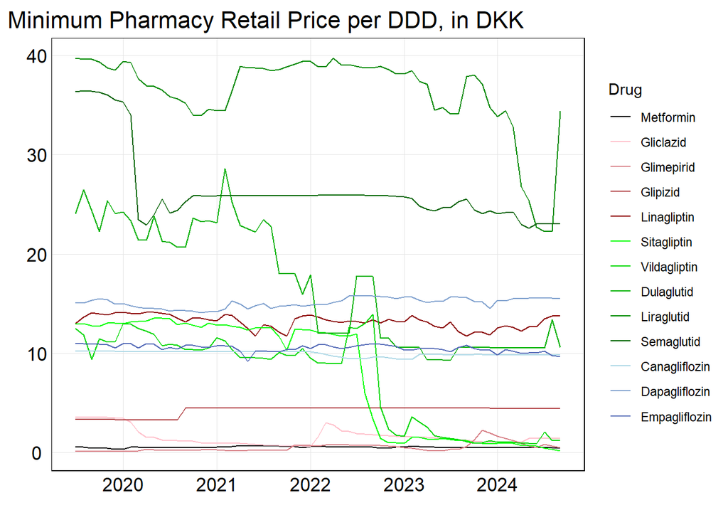

```r
dfforplot |>
  filter(a_min_prpddd<100
         & compound %in% kept_compounds) |>
  ggplot(aes(x = month, y = a_min_prpddd, colour = compound)) +
  geom_line() +
  scale_colour_manual(values = colours_compounds) +
  scale_x_continuous(breaks = seq.Date(as.Date("2020-01-01"), as.Date("2025-12-01"), by = "year"),
                     labels = format(seq.Date(as.Date("2020-01-01"), as.Date("2025-12-01"), by = "year"), "%Y")) +
  labs(title = "Minimum Pharmacy Retail Price per DDD, in DKK",
       x = "",
       y = "",
       colour = "Drug") +
  hen_theme()
```

**Oops**, I messed up. The colours do not fit anymore. Will fit the colours to the new more limited amount of compounds.

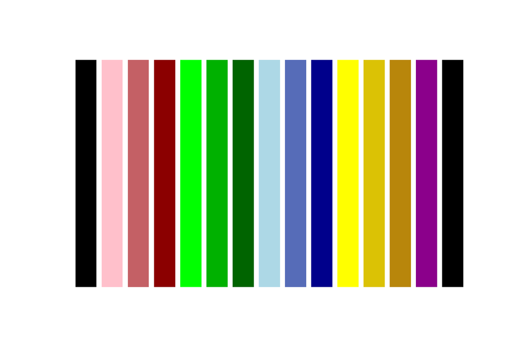

```r
met_colours  <- colorRampPalette(c("black"))(1)
su_colours  <- colorRampPalette(c("pink","darkred"))(3)
dpp4_colours   <- colorRampPalette(c("green","darkgreen"))(3) # NB THIS WORKS BECAUSE THE FIRST 5 ARE DPP4, 6 are GLP1, etc etc.
glp1_colours   <- colorRampPalette(c("lightblue","darkblue"))(3)
sglt2_colours  <- colorRampPalette(c("yellow","#b8860b"))(3)
tir_colours  <- colorRampPalette(c("#8b008b"))(1)
colours_compounds <- c(met_colours,
                su_colours,
                dpp4_colours,
                glp1_colours,
                sglt2_colours,
                tir_colours) # combine
barplot(rep(1,15), col=colours_compounds, border = "white", axes = FALSE)
```

Now try again.

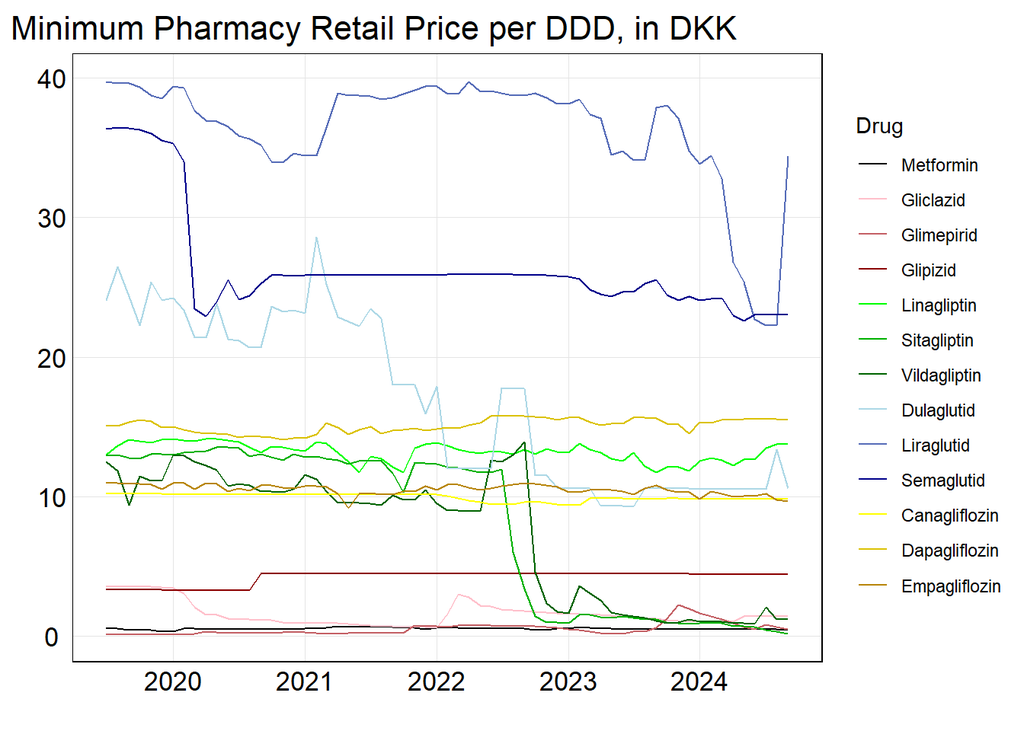

```r
dfforplot |>
  filter(a_min_prpddd<100
         & compound %in% kept_compounds) |>
  ggplot(aes(x = month, y = a_min_prpddd, colour = compound)) +
  geom_line() +
  scale_colour_manual(values = colours_compounds) +
  scale_x_continuous(breaks = seq.Date(as.Date("2020-01-01"), as.Date("2025-12-01"), by = "year"),
                     labels = format(seq.Date(as.Date("2020-01-01"), as.Date("2025-12-01"), by = "year"), "%Y")) +
  labs(title = "Minimum Pharmacy Retail Price per DDD, in DKK",
       x = "",
       y = "",
       colour = "Drug") +
  hen_theme()
```

Now that looks much better. Now let’s make the final graph, using `facet_wrap()` to distinguish between the minimum and maximum PRP per DDD.